# Objective

## Background:

[figure not shown]

Crack detection has vital importance for structural health monitoring and inspection. This project contains the attempt to train a `resnet18` neural network to detect Cracks and denote the images that contain cracks as `positive` and images with no cracks as `negative`. It will display some mislabeled samples for evaluation.

## Model:

The resnet18 is an open source CV model that is light-weight enough to be run on a laptop as long as there aren't too many epochs. Regardless, training on this device took about 7m27s per epoch but achieved an accuracy of 99.36% on the validation set.

[figure not shown]

## Discussion:

Unfortunately, visual human analysis of misclassified samples was not feasable for this task; the first few misclassifications are presented below. For the future, model design to include a failure analysis method would be necessary. As a proof-of-concept, this is functional enough.

[figure not shown]

# Imports and Auxiliary Functions

```python
# visualization
from PIL import Image
import matplotlib.pylab as plt
import seaborn as sns
# operations
import pandas as pd
import numpy as np
import time
import os
import pickle
# dataset retrieve
import requests
import zipfile
import os
from pathlib import Path
# AI tools
import torch
from torch.utils.data import Dataset, DataLoader
import torchvision.transforms as transforms
import torch.nn as nn
import torchvision.models as models
from sklearn.metrics import confusion_matrix
```

## Dataset retrieval

```python
def download_and_extract_zip(url, extract_dir):
    # Create the resources directory if it doesn't exist
    Path(extract_dir).mkdir(exist_ok=True)

    # Download the zip file
    response = requests.get(url, stream=True)
    response.raise_for_status()  # Raises an HTTPError if the status is 4xx, 5xx

    # Save the zip file temporarily
    temp_zip = "temp.zip"
    with open(temp_zip, "wb") as f:
        for chunk in response.iter_content(chunk_size=8192):
            f.write(chunk)

    # Extract the contents to the resources directory
    with zipfile.ZipFile(temp_zip, 'r') as zip_ref:
        zip_ref.extractall(extract_dir)

    # Remove the temporary zip file
    os.remove(temp_zip)
```

```python
# dataset, if needed
url = "https://s3-api.us-geo.objectstorage.softlayer.net/cf-courses-data/CognitiveClass/DL0321EN/data/images/concrete_crack_images_for_classification.zip"
directory="resources/data"
if not os.path.exists("./concrete_crack_images_for_classification.zip"):
    try:
        download_and_extract_zip(url,directory)
        print("Successfully downloaded and extracted zip file to resources folder")
    except Exception as e:
        print(f"An error occurred: {e}")
else:
    print("dataset present")
```

```
dataset present
```

# Loading Images and Initial Testing

## Examine Files

```python
# set dirs
negative='/Negative'
negative_file_path=directory+negative
positive="/Positive"
postive_file_path= directory+positive
cracked={1:"damaged",0:"undamaged"}
```

```python
negative_files=[os.path.join(negative_file_path,file) for file in os.listdir(negative_file_path) if file.endswith(".jpg")]
negative_files.sort()
# verify neg
print(negative_files[:3])
positive_files=[os.path.join(postive_file_path,file) for file in os.listdir(postive_file_path) if file.endswith(".jpg")]
positive_files.sort()
# verify pos
print(positive_files[:3])
number_of_samples = len(positive_files) + len(negative_files)
print("the number of samples total is",number_of_samples)
```

```
['resources/data/Negative\\00001.jpg', 'resources/data/Negative\\00002.jpg', 'resources/data/Negative\\00003.jpg']
['resources/data/Positive\\00001.jpg', 'resources/data/Positive\\00002.jpg', 'resources/data/Positive\\00003.jpg']
the number of samples total is 40000
```

## Test Display

using `Image` from **PIL**, test loading the first image :

```python
def plot_imgs(img_set:list,label_list=[],max_display=2,export=False):
    fig, axs = plt.subplots(max_display//2,2,layout=None)
    for (ind,(img,ax)) in enumerate(zip(img_set[:max_display],axs.flat)):
        image = Image.open(img)
        ax.imshow(image)
        ax.axis("off")
        if any(label_list):
            label = cracked[int(label_list[ind].data.item())]
            ax.set_title("label({}) = {}".format(ind,label),fontdict={"fontsize":8})
        else:
            ax.set_title(img[-18:],fontdict={"fontsize":8})
    if export:
        plt.savefig("example_conc.png", bbox_inches="tight")
```

### 'Negative' Image (No Cracks)

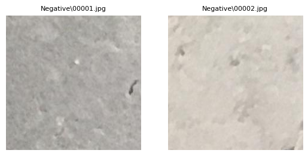

```python
plot_imgs(negative_files,max_display=2)
```

### 'Positive' Image (With Cracks)

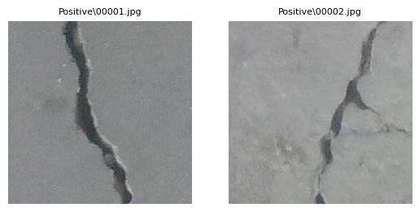

```python
plot_imgs(positive_files,max_display=2)
```

## Assign Labels to Images

With respect to each element, the even elements are class `1` and the odd elements class `0`.

```python
Y=torch.zeros([number_of_samples]).type(torch.LongTensor)
Y[::2]=1
Y[1::2]=0
```

## Create list all_files

- even indexes contain the path to positive
- odd indexes contain the path to negative

```python
all_files = [""]*40000
all_files[::2] = positive_files[:]
all_files[1::2] =negative_files[:]
```

### Test display

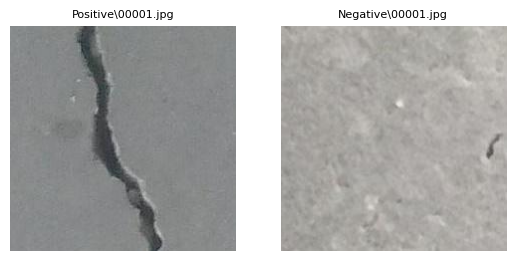

```python
# preview dataset
plot_imgs(all_files,max_display=2, export=True)
```

## Training and Validation Split

first 30000 samples are used for training

```python
def mini_set(x,y,lim, train):
    if train:
        X=x[:lim]
        Y=y[:lim]
    else:
        X=x[lim:]
        Y=y[lim:]
    print(X[:2],Y[:2])
    return X,Y
test_x,test_Y = mini_set(all_files,Y,30000,False)
```

```
['resources/data/Positive\\15001_1.jpg', 'resources/data/Negative\\15001.jpg'] tensor([1, 0])
```

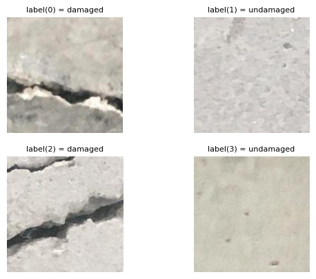

```python
plot_imgs(test_x,test_Y,4)
```

# Create Datasets

If the parameter `train` is set to `True`, it will use the first 30 000 samples as training data; otherwise, the remaining samples will be used as validation data.

```python
class My_Dataset(Dataset):

    # Constructor
    def __init__(self,transform=None,train=True):
        directory="resources/data"
        negative='/Negative'
        positive="/Positive"
        negative_file_path=directory+negative
        positive_file_path=directory+positive

        positive_files=[os.path.join(positive_file_path,file) for file in  os.listdir(positive_file_path) if file.endswith(".jpg")]
        positive_files.sort()
        negative_files=[os.path.join(negative_file_path,file) for file in  os.listdir(negative_file_path) if file.endswith(".jpg")]
        negative_files.sort()

        self.all_files=[None]*number_of_samples
        self.all_files[::2]=positive_files
        self.all_files[1::2]=negative_files
        # transform if needed
        self.transform = transform
        #torch.LongTensor
        self.Y=torch.zeros([number_of_samples]).type(torch.LongTensor)
        self.Y[::2]=1
        self.Y[1::2]=0

        if train:
            self.all_files=self.all_files[:30000]
            self.Y=self.Y[:30000]
            self.len=len(self.all_files)
        else:
            self.all_files=self.all_files[30000:]
            self.Y=self.Y[30000:]
            self.len=len(self.all_files)

    # Get the length
    def __len__(self):
        return self.len

    # Getter
    def __getitem__(self, idx):
        # load img
        image=Image.open(self.all_files[idx])
        y=self.Y[idx]
        # apply transform
        if self.transform:
            image = self.transform(image)

        return image, y
```

## Test Dataset

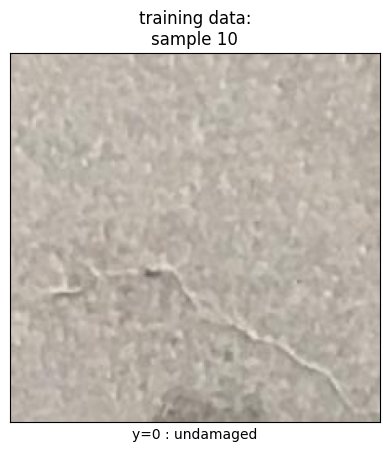

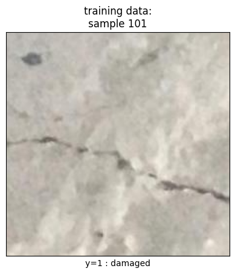

```python
train_dataset=My_Dataset(train=True)
samples = [9,100]
for sample in samples:
    plt.imshow(train_dataset[sample][0])
    label = train_dataset[sample][1].item()
    plt.xlabel("y="+str(label)+" : "+cracked[label])
    plt.title("training data:\nsample {}".format(int(sample)+1))
    plt.xticks([])
    plt.yticks([])
    plt.savefig(f"conc_example_{sample}.png", bbox_inches="tight")
    plt.show()
```

## Transform Object and Dataset Object

```python
mean = [0.485, 0.456, 0.406]
std = [0.229, 0.224, 0.225]
transform =transforms.Compose([ transforms.ToTensor(), transforms.Normalize(mean, std)])
```

## Train,Test Split

```python
dataset_train=My_Dataset(transform=transform,train=True)
dataset_val=My_Dataset(transform=transform,train=False)
dataset_train[0][0].shape, dataset_train[0][1].shape
```

```
(torch.Size([3, 227, 227]), torch.Size([]))
```

We see that it's a color image with three channels:

```python
size_of_image=3*227*227
size_of_image
```

```
154587
```

# Helper Functions

```python
#plot results
def plot_results(training_results, title_1,export=False):
    fig,ax1 = plt.subplots()
    color="tab:red"
    ax1.plot(training_results["loss"],color=color)
    ax1.set_xlabel("epoch",color=color)
    ax1.set_ylabel("total loss",color=color)
    ax1.tick_params(axis="y",color=color)
    ax1.set_title(title_1)
    ax1.set_xticks(np.arange(len(training_results)))
    ax1.set_xticklabels(list(np.arange(1,len(training_results)+1)))
    ax2 = ax1.twinx()
    color = "tab:blue"
    ax2.set_ylabel("validation accuracy",color=color)
    ax2.plot(training_results["acc"],color=color)
    ax2.tick_params(axis="y",color=color)
    fig.tight_layout()
    if export:
        fig.savefig(f"{title_1}_results_e{len(training_results)}.png",bbox_inches="tight")
    plt.show()
```

# Construct: Linear Model

```python
torch.manual_seed(0)
```

```
<torch._C.Generator at 0x1b6547c82d0>
```

### Basic Linear Model

```python
class my_model(nn.Module):
    def __init__(self,ins,outs):
        super(my_model, self).__init__()
        self.linear = nn.Linear(ins,outs)
    def forward(self,x):
        x=self.linear(x)
        return x
model = my_model(size_of_image,2)
```

## Training Function

```python
# TODO turn into function, setup results dict
def train_model(model,t_load,v_load,optimizer,crit,n_epochs=1,transformed=False):
    # training result bucket
    train_results={"loss":[],"acc":[],"time":[]}

    for epoch in range(n_epochs):
        start_time = time.time()
        for x, y in t_load:
            model.train()
            optimizer.zero_grad()
            # predict
            if transformed:
                x_ = x.view(-1,size_of_image)
                z=model(x_)
            else:
                z=model(x)
            # calculate loss
            loss = crit(z,y)
            # calculate gradients of parameters
            loss.backward()
            # update parameters
            optimizer.step()

        total_corr=0
        for x_test, y_test in v_load:
            # set model_resnet to eval
            model.eval()
            #make a prediction

            if transformed:
                x_ = x_test.view(-1,size_of_image)
                z=model(x_)
            else:
                z=model(x_test)
            #find max
            _,y_hat= torch.max(z.data,1)
            total_corr+=(y_hat==y_test).sum().item()
        stop_time = time.time()
        elapsed_time = stop_time - start_time
        print(f"{elapsed_time:.2f} seconds elapsed in epoch {epoch+1}")
        acc = total_corr/len(v_load.dataset)
        train_results["time"].append(elapsed_time)
        train_results["acc"].append(acc)
        train_results["loss"].append(np.float64(loss.data))
    return train_results, model
```

### Data Loaders

```python
train_load = DataLoader(dataset_train,5)
val_load = DataLoader(dataset_val,1)
```

# Train Model: Linear

#### Hyperparameters

```python
learning_rate = 0.1
momentum =0.1
optimizer = torch.optim.SGD(params=model.parameters(),lr=learning_rate,momentum=momentum)
crit = nn.CrossEntropyLoss()
transformed = True
epochs = 10
```

```python
def train_or_load(model_name,model,train_load,val_load,optimizer,crit,epochs,transformed):
    csv_path = f"{model_name}_results.csv"
    model_path = f"{model_name}.pkl"
    if os.path.exists(model_path):
        with open(model_path,"rb") as file:
            model = pickle.load(file)
        results = pd.read_csv(csv_path,index_col=0)
    else:
        tmp_results,model = train_model(model,train_load,val_load,optimizer,crit,epochs,transformed)
        results = pd.DataFrame(tmp_results)
        # save results
        with open(model_path,"wb") as file:
            pickle.dump(model,file)
        results.to_csv(csv_path)

    return model,results
```

```python
model,lingreg_results = train_or_load("linreg",model,train_load,val_load,optimizer,crit,epochs,transformed)
```

```python
lingreg_results
```

|  | loss | acc | time |
| --- | --- | --- | --- |
| 0 | 1351.493408 | 0.7930 | 58.803360 |
| 1 | 0.000000 | 0.8326 | 55.196217 |
| 2 | 0.000000 | 0.8289 | 47.842778 |
| 3 | 0.000000 | 0.8340 | 47.843730 |
| 4 | 35.672268 | 0.8174 | 49.558813 |
| 5 | 0.000000 | 0.8091 | 49.555046 |
| 6 | 0.000000 | 0.8265 | 48.151616 |
| 7 | 0.000000 | 0.8291 | 1296.365067 |
| 8 | 0.000000 | 0.8147 | 47.485600 |
| 9 | 0.000000 | 0.7797 | 44.986489 |

# Results: Linear

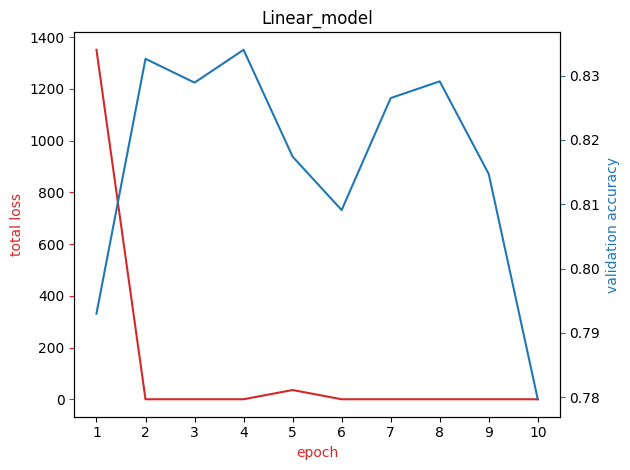

```python
# show model training results
plot_results(lingreg_results,"Linear_model")
```

```python
best_epoch = np.argmax(lingreg_results["acc"])
top_acc = lingreg_results["acc"][best_epoch]
top_acc
```

```
np.float64(0.834)
```

# Construct: resnet18

Load a pre-trained model `resnet18`

```python
# Load pre-trained resnet18
weights = models.ResNet18_Weights.DEFAULT
model_resnet = models.resnet18(weights=weights)
# lock params
for para in model_resnet.parameters():
    para.requires_grad = False
```

```python
out_n_inputs= model_resnet.fc.in_features
```

Replace the output layer `nn.Linear` to classify 2 classes

```python
model_resnet.fc = nn.Linear(out_n_inputs,2)
```

## Hyperparameters

```python
crit = nn.CrossEntropyLoss()
optimizer = torch.optim.SGD([parameters for parameters in model_resnet.parameters() if parameters.requires_grad],lr=0.01, momentum=0.9)
# data loaders
t_load = DataLoader(dataset_train,100)
v_load = DataLoader(dataset_val,100)
epochs = 5
transformed = False
```

# Train Model: Resnet18

```python
model_resnet,res_results = train_or_load("resnet18",model_resnet,t_load,v_load,optimizer,crit,epochs,transformed)
```

```python
res_results
```

|  | loss | acc | time |
| --- | --- | --- | --- |
| 0 | 0.056970 | 0.9908 | 440.582125 |
| 1 | 0.042952 | 0.9927 | 427.459350 |
| 2 | 0.034230 | 0.9933 | 911.879377 |
| 3 | 0.029589 | 0.9933 | 447.487593 |
| 4 | 0.026832 | 0.9936 | 458.982433 |

# Results: Resnet18

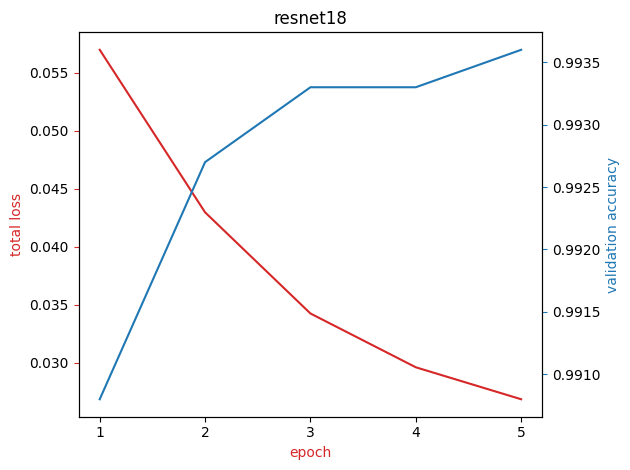

```python
plot_results(res_results,"resnet18",export=True)
```

# Analysis

## Confusion Matrix

```python
def get_cm(model,dataset_val):
    y_hat = []
    y_true = []
    model.eval()
    for (x,y) in dataset_val:
        x=x.unsqueeze(0)
        z = model(x)
        y_hat.append(torch.max(z.data,1)[1])
        y_true.append(y)
    return confusion_matrix(y_true,y_hat)
```

```python
resnet_cm = get_cm(model_resnet,dataset_val)
```

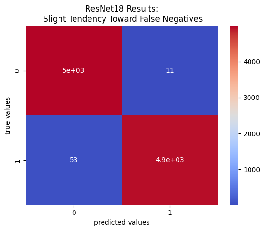

```python
sns.heatmap(resnet_cm,annot=True,cmap=sns.color_palette("coolwarm",as_cmap=True))
plt.title("ResNet18 Results:\n Slight Tendency Toward False Negatives")
plt.xlabel("predicted values")
plt.ylabel("true values")
plt.savefig("conf_mat.png", bbox_inches="tight")
plt.show()
```

## Examine misclassified samples

```python
#show classifications
def show_class(model,v_dataset, max_samples=2):
    miss_data={"idx":[],"pred":[],"y_true":[],"x_true":[]}
    count=0
    for idx, (x,y) in enumerate(v_dataset):

        model.eval()
        x=x.unsqueeze(0)
        z = model(x)
        _,y_hat=torch.max(z.data,1)

        if (y_hat==0 and y==1):
            miss_data["idx"].append(idx)
            miss_data["pred"].append(y_hat)
            miss_data["x_true"].append(x)
            miss_data["y_true"].append(y)
            count+=1
        if count >= max_samples:
            return miss_data
max_samples = 5
misclassified = show_class(model_resnet,dataset_val,max_samples)
```

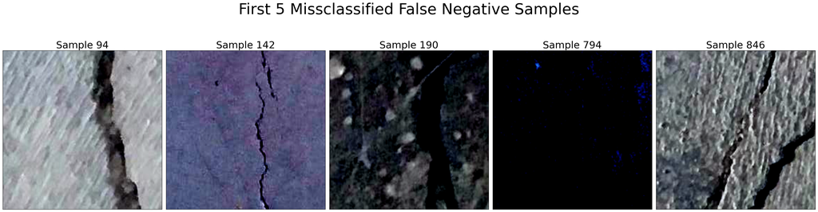

```python
fig = plt.figure(figsize=(30,9))
fig.suptitle(f"First {max_samples} Missclassified False Negative Samples",fontsize=40)
for ix,i in enumerate(misclassified["x_true"]):
    # getting values, labels
    idx=misclassified["idx"][ix]
    y_hat=misclassified["pred"][ix]
    y=misclassified["y_true"][ix]
    pred_label = cracked[int(y_hat.data.item())]
    true_label = cracked[int(y)]
    # reformating image
    image = i.numpy().squeeze().T
    image /= np.amax(image)
    i_ = np.clip(image,0,1)
    # plot
    title = f"Sample {idx}"
    subs = int(str(15)+str(ix+1))
    ax = plt.subplot(subs)
    plt.imshow(i_)
    ax.set_title(title,fontsize=26)
    ax.get_xaxis().set_ticks([])
    ax.get_yaxis().set_ticks([])
plt.tight_layout()
plt.savefig("missclass.png", bbox_inches="tight")
plt.show()
```